# Day 1: Getting data into shape

Tidyverse world

Ben Fanson https://bfanson.github.io/2024DADAworkshop/ (Arthur Rylah Institute)https://www.ari.vic.gov.au/  
2024-09-04

# Day’s objectives

- Understand workflow, why it is important, and how to do it using Rstudio/R
- Have an understanding of the tidyverse framework and its key packages
- Provide a bit of context/framework to working in R as many of us have learned piecemeal
- Work through an example

# Key packages

[figure not shown]

[figure not shown]

[figure not shown]

[figure not shown]

[figure not shown]

[figure not shown]

[figure not shown]

# Workshop project: Wetland Data

Click over to [dataset webpage](https://bfanson.github.io/2024_DADA_workshop/dataset.html) for overview of the wetland data

# Workflows

## Basic of data analysis workflow

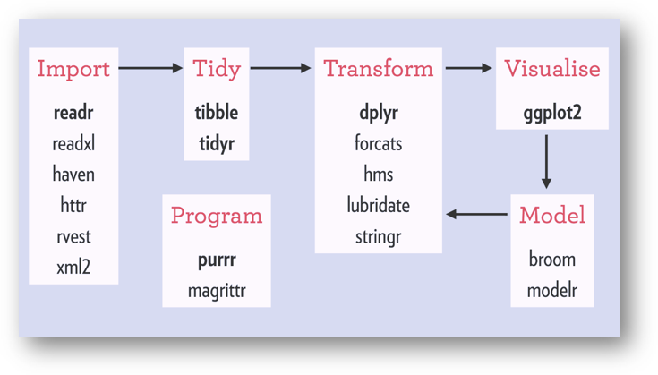

## Example of a R/Rstudio workflow

So those are the basics and suspect most will be rather familiar with that workflow. But, examples speak volumes. Let’s go through an example of the fundamentals of my R/Studio workflow:

- Project folder structure

[figure not shown]

- Data storage: three main folders raw, rds, spatial

[figure not shown]

- R scripts : import/data cleaning, analysis

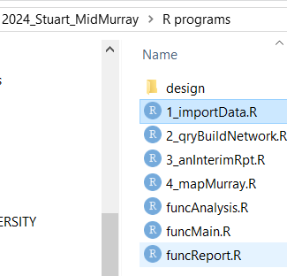

- structure within the scripts (example of `importData.r`)

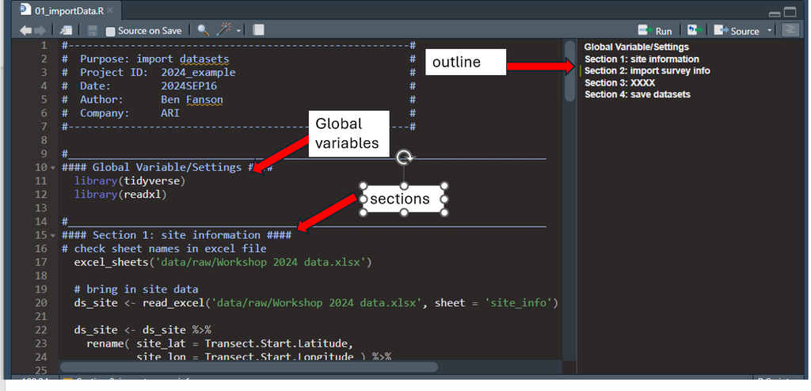

- Report writing: Rmarkdown file [day3]

## Advantages of workflow

- “laziness” in data analysis programming
  - reduce cognitive load
  - reduce distractions (rabbitholes/“the weave”)
  - efficiency
- collaborations
  - a logical workflow makes for easy collaborations
- reproducibility
  - logical, clean workflows minimise error
  - every step is explicit in the code [no black boxes]

## Caveat on my R/Rstudio workflow

My R/Rstudio workflow has evolved over the years and reflects historical contingencies (e.g. working as analyst in pharmaceutical for 9 months, influential people I happened to meet).

This workshop will work off this framework but this workflow might not fit you per se. However, for those developing their workflow, it is useful to have an initial foundation in which to work off. So, as we go through this workshop, think about how you personalise the workflow for you:

- how might you integrate your current process with the workflow presented?
- what unique aspects of your work need to be integrated into the workflow?
- what is the role of collaborators and meshing workflows?

Upfront thinking about this is not time-wasted. If you have a great structure that inherently works for you, you will be more efficient.

# Ready, set, go….

Okay, we have the data and understand the project goals, design, and key questions. Let’s go through the basic steps to get going…

## P1: Setup your project folder

1. Create Rproject using Rstudio

[figure not shown]

2. Create folder structure

[figure not shown]

Cheatsheets had been made for many packages and are really useful. See Rstudio IDE to Positron https://github.com/posit-dev/positron/wiki for note about new IDE

3. Create an `importData.r` script

[figure not shown]

Let’s talk a look at my standard import script

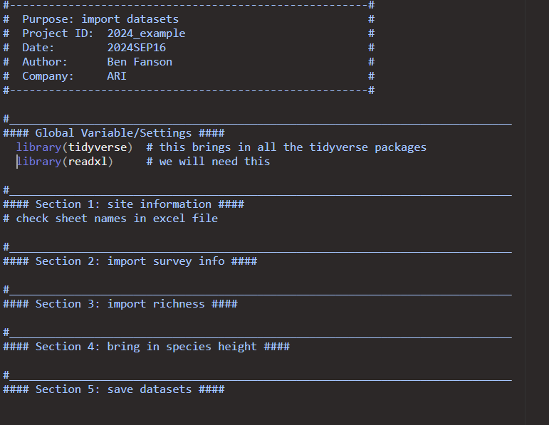

Click the outline button in upper right of the script screen to show the outline of script. The outline is created by the #### Text ####

### Tidyverse

At the top of my script, I put `library(tidyverse)`

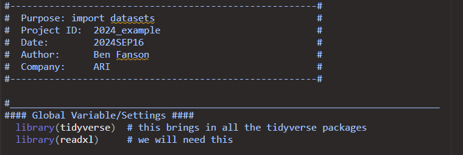

Tidyverse is big topic but here are key points that I want you know:

1. Tidyverse is an opinionated approach to data analysis and has spurred a movement of tidy-everything (tidygraphs, tidybayes, sf package, and so much more)
2. Rather than a package per se, it is really a collection of packages (aka meta-package)
3. Tidyverse goals
   - make R code more consistent
   - make R code more readable for humans (e.g. uses words like filter, select, mutate, summarise)
   - create a cult

### Side note - Version control/GitHub [Advanced topic]

As part of my due-diligence, I have to mention version control. In short, version control is external software that keeps track of all your changes (so you can go back if something breaks in your code) and very helpful with collaborations (e.g. allowing you both code away and then merging those changes).

For R/Rstudio, Git/GitHub is the most popular (and can be directly integrated). Now, **Git is the version control software locally on your computer** and it does the tracking of all changes In contrast, **GitHub is an online platform** in which you can upload those changes (and project folder/files) and is mainly useful for the collaboration/sharing (plus some other useful features)

**Key points on Git/GitHub:**

CRAN is repository for packages and is teh default place to look for a package. As CRAN has certain rules/time-lags, some by-pass using other repositories like GitHub

## P2: Importing data

After setting up environment, on to the import stage

### import philosophy

In my workflow, I view data files as “locked(/read-only)”. This is part of the reproducibility pathway. So this means for me:

- I do not change filenames once the data go in that folder [e.g. if you do, you will forget where your file came and have to go digging]
- I will not touch anything in the files.
  - Either I code around (so anyone can see the change)
  - Send back to get it fix

### Key importing functions

#### excel files

For this, we will use `readxl` package

There are other read excel packages but this one just works

```r
  library(readxl)
  read_xls()
  read_xlsx()
```

You should be aware of how it handles missing data. In `read_xlsx()` you can specify an argument `na=` to indicate what cell values should be treated as missing.

```r
  library(readxl)
  read_xlsx( 'data/raw/missing.xlsx', na='' ) # default
```

```
# A tibble: 5 × 2
    var missing
  <dbl> <chr>
1     1 NA
2     2 na
3     3 .
4     4 <NA>
5     5 Na
```

```r
  read_xlsx( 'data/raw/missing.xlsx', na=c('NA','na') )
```

```
# A tibble: 5 × 2
    var missing
  <dbl> <chr>
1     1 <NA>
2     2 <NA>
3     3 .
4     4 <NA>
5     5 Na
```

#### csv/txt

For reading csv/txt

```r
# from readr package in tidyverse
  read_csv(file_name)    # comma delimited
  read_table(file_name)  # tab delimited
  read_delim(file_name, delim='#') # or other type of delimited

  ?read_csv  # to see arguments/options for importing
```

#### Database [Advanced]

Some possible packages to check:

- `RMySQL`: This package allows you to connect to MySQL databases and execute SQL queries1.
- `RPostgreSQL`: This package is designed for connecting to PostgreSQL databases1.
- `RSQLite`: This package is used for SQLite databases and is great for lightweight, serverless database applications1.
- `RODBC`: This package provides a way to connect to any database that supports ODBC (Open Database Connectivity)1.
- `RJDBC`: This package uses Java Database Connectivity (JDBC) to connect to a wide variety of databases1.

### Importing our project files

```r
#_____________________________________________________________________________
#### Section 1: site information ####
# check sheet names in excel file
  excel_sheets(file_excel)

  # bring in site data
  ds_site <- read_excel(file_excel, sheet = 'site_info')

  # take a look
  head(ds_site)  # quick peak
  View(ds_site)  # check out a datatable version...can also just click the object in the
                 # environment panel in upper right
  names(ds_site)  # have a look at object names
```

## P3: Data cleaning

### Overview of basics

Now we have the first file in. That is the easy bit. However, we need to clean up dataset(s) so that they are ready for analysis. By cleaning I mean: - column management + renaming columns for coding + drop extra columns and extra rows + makes sure column types (e.g. numeric, character, factors, date) are correct + data entry errors in columns + string manipulations - check design (aka get intimate ❤️ with the data) + extract out the design elements to confirm it matches (or identity where is does not) + missing data - join together response variables, design, and covariates - restructure data for analysis (e.g. long vs wide form)

### column management

#### dropping/keeping columns - `select()`

the `select()` is used to select the columns you want. Here, we use it to drop the two columns we do not. The ‘…10’ was created automatically by `read_excel()` and not needed. We delete the columns using (-) negative in-front of the column we want to drop. We also learn if a column name has whitespace (or other special characters like %, #, …) you need to use quotes to refer to it.

```r
  # let's delete that the extra column... use select(data, -var)
  ds_site <- select( ds_site, -...10)  # drop the ...10
#  ds_site <- select( ds_site, -Drop me)  # this does not work
  ds_site <- select( ds_site, -"Drop me")  # need to use either "Drop me" or `Drop me` if you have whitespace
```

#### renaming columns - `rename()`

You will want to rename columns. It is important to think about what makes a good column name for you. I stick to the following

- no whitespaces, no special characters, not too long, (for me) all lowercase
- prefixes or suffixes (useful for select functions) [e.g. dates are dt_, datetime is dttm_, site info is site_)

```r
  # now, let's rename [I will show two ways: rename() and within select() ]
  ds_site <- ds_site %>%
    rename( site_lat = Transect.Start.Latitude,
            site_lon = Transect.Start.Longitude ) %>%
    select(cma, wetland=wetland_name, transect_id, fence, grazing, starts_with('site_') )
```

#### check column type and convert - `mutate()`

When you want to create a new column or modify an existing column, `mutate()` is the key function. We used it to convert lat/lon from character to numeric.

```r
 # now, let's check column type
  head(ds_site)  # <chr> = character

  # convert lat/lon to numeric...need to use mutate and will use as.numeric()
  ds_site <- mutate(ds_site,
                    site_lon_n = as.numeric(site_lon),
                    site_lat_n = as.numeric(site_lat) ) # note the warning
  filter(ds_site, is.na(site_lon_n)|is.na(site_lat_n) )  # warning cause it was missing..will get later from researcher

  # now, I want to keep the site_lat/site_lon column but as numeric
  ds_site <- select(ds_site, -site_lon, -site_lat) %>%
              rename( site_lat = site_lat_n, site_lon = site_lon_n )
  head(ds_site) # looking good
```

```r
# commmon conversion functions
  as.numeric()
  as.character()
  as.factor()
  as_date()  # note there is as.Date() and as_date()...use the later
  as_datetime()  # note there is as.Date() and as_date()...use the later
```

For dates, this is another whole topic. I highly recommend you use the `lubridate` package for all date handling. See [date webpage](https://bfanson.github.io/2024_DADA_workshop/d1_lubridate.html) for a bit more info

For factors, be very careful when converting…

```r
# factors are in essence an ordinal in that they are stored as numbers with labels
  intensity <- c('low','medium','high')
  intensity
  class(intensity) # character
  f_intensity <- as.factor(intensity)
  f_intensity # now a factor and note the levels
  as.numeric(f_intensity) # you get numbers

# here is where the problem comes in...
  ds_fish  <- data.frame( fish_id = c(1,2,6,7) ) # say you have fish id as a number
  ds_fish  <- mutate(ds_fish, f_fish_id = factor(fish_id) ) # you convert fish_id to a factor for a model
  mutate(ds_fish, fish_id = as.numeric(f_fish_id) ) # you want to join it to another dataset and it needed to be numeric, you use as.numeric() you get the wrong numbers
  # note - this use to be a bigger problem pre-tidyverse0
```

#### data issues and using `filter()`

Next, we checked each column of interest to see if it matched our expectations. We introduced a string function `str_to_sentence()` to help. You also saw `filter()` and how to use that. The operators for `fitler()` are ==, !=, %in%. <aside>There are tons of string functions. Check the cheatsheet.

We also learned about `pull(data, var)` vs `data$var` way of getting a specif column from the dataset

```r
# first, you need to learn to grab a single column from a dataset
  pull(ds_site, cma)  # this is tidyverse way
  #vs
  ds_site$cma  # this is the old base way

  # I will use $ method here as this is more common (or maybe I am just old(-school) )
  table(ds_site$cma) # looks good

  table(ds_site$wetland) # looks good, no misspellings obvious, numbers not exactly 10

  table(ds_site$fence) # oops, yes vs Yes...capitalisation matters
  ds_site <- mutate( ds_site, fence = str_to_sentence(fence) )  # let's use a string function
  table(ds_site$fence) # Too easy!

  table(ds_site$grazing) # okay, was excepting just Crash/Press - was not expecting
  ds_site <- filter(ds_site, grazing != 'NIL' )  # ! is used to say not
  ds_site <- filter(ds_site, grazing %in% c('Crash','Press' ) )  # or you inverse way
  table(ds_site$grazing) # all good
```